# HW3

S??la Ayd??n

19.11.2018

## Task 1

### 1-A - Plotting the location

To plot the location of an observation, cumsum() is used to sum up all accelerations to find velocities at each time point. Then to find the average velocities at each time point the averages of two consecutive velocities are computed. When the average velocities are summed again using cumsum() the location at each time point is obtained. Below is the code for the x location:

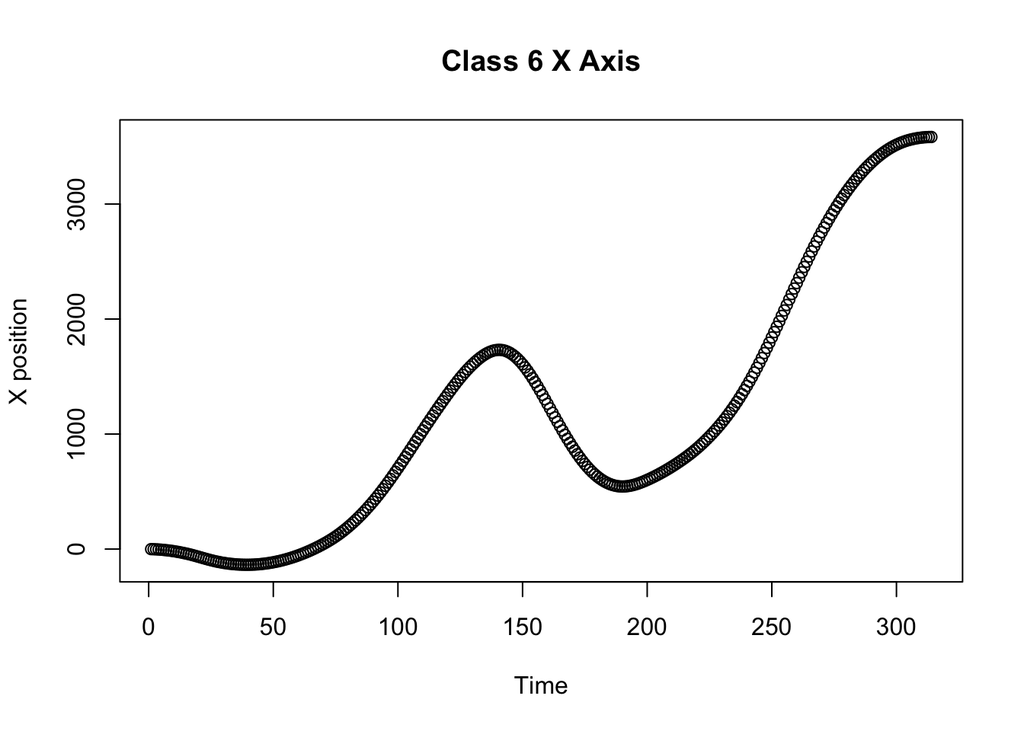

```r
class=x_train[,1]
n=1
x=x_train[n, 2:ncol(x_train)]
x=t(x)
x=t(cumsum(x))
loc_x=cumsum((x[,1:ncol(x)-1]+x[,2:ncol(x)])/2)
plot(loc_x, main = "Class 6 X Axis", xlab = "Time", ylab = "X position")
```

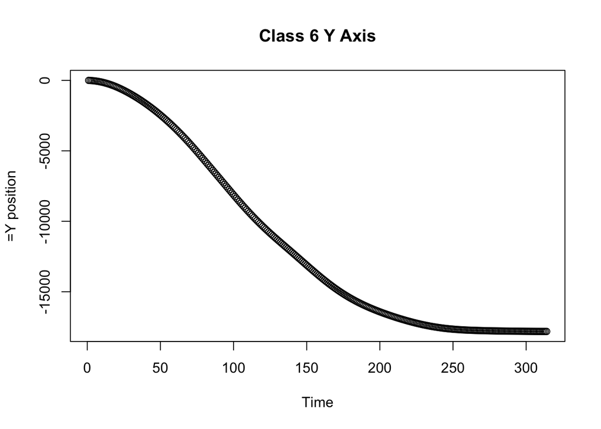

```r
plot(loc_y, main = "Class 6 Y Axis", xlab = "Time", ylab = "=Y position")
```

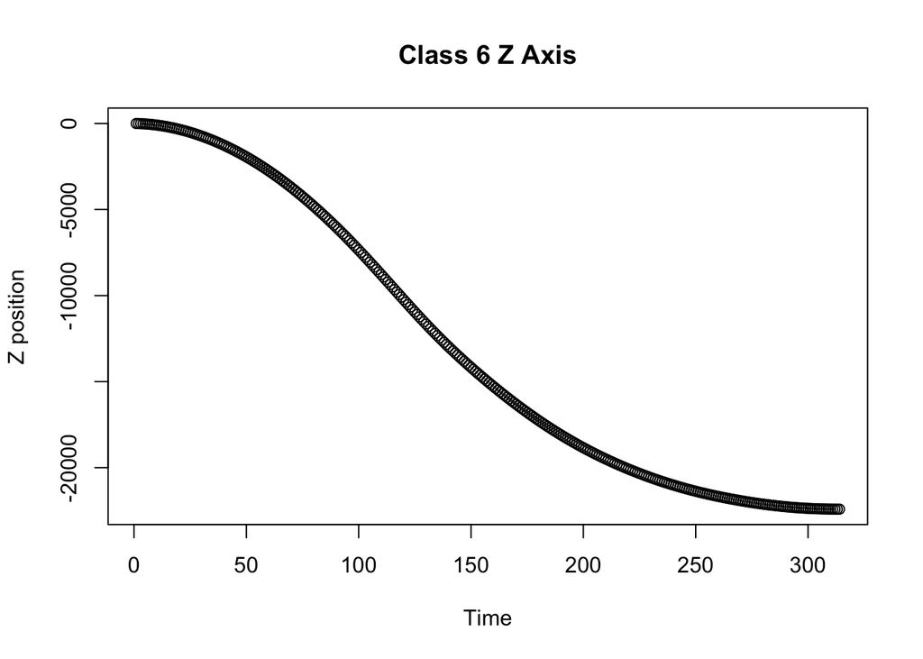

```r
plot(loc_z, main = "Class 6 Z Axis", xlab = "Time", ylab = "Z position")
```

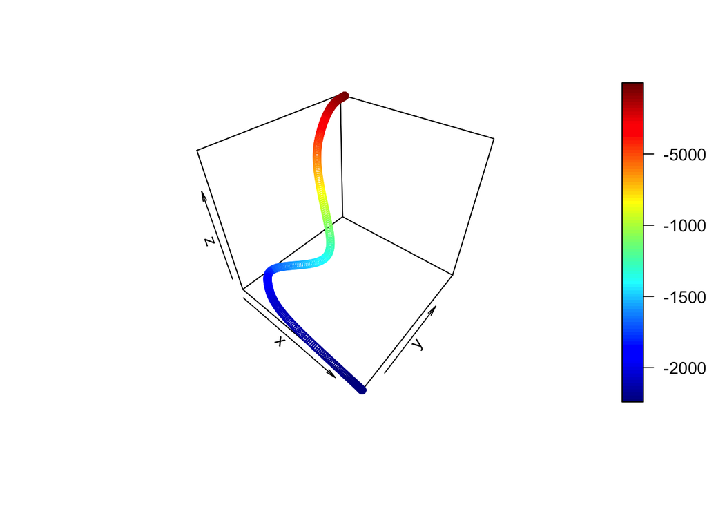

```r
plot3D::scatter3D(loc_x,loc_y,loc_z,scale=TRUE,center=TRUE)
```